# Morison Load Calculation on Offshore pile

## Objective

In this notebook, we will calculate the hydrodynamic wave load acting on a vertical offshore monopile using the Morison Equation.

The example problem is:

- Monopile Diameter = 1.6 m
- Water Depth = 30 m
- Wave Height = 6 m
- Wave Period = 10 sec
- Water Density = 1025 kg/m³

The pile is divided into multiple vertical segments and the force on each segment is calculated individually.

## Physical Understanding

When waves pass an offshore structure:

- Water particles move horizontally and vertically
- These moving particles create:
  - Drag Force
  - Inertia Force

The total force is calculated using the Morison Equation.

```python
import numpy as np
import matplotlib.pyplot as plt

# Plot settings
plt.rcParams['figure.figsize'] = (10,6)
plt.rcParams['font.size'] = 12
```

## Given Data

| Parameter | Value |
| --- | --- |
| Pile Diameter | 1.6 m |
| Water Depth | 30 m |
| Wave Height | 6 m |
| Wave Period | 10 sec |
| Water Density | 1025 kg/m³ |
| Drag Coefficient (C_d) | 0.65 |
| Inertia Coefficient (C_m) | 2.0 |

### Deep Water Wave Length

For deep water condition:

$$ L = \frac{gT^2}{2\pi} $$

Where:

- $L$ = Wave length
- $g$ = Gravitational acceleration
- $T$ = Wave period

### Wave Number

$$ k = \frac{2\pi}{L} $$

Wave number defines how rapidly the wave oscillates spatially.

### Angular Frequency

$$ \omega = \frac{2\pi}{T} $$

Angular frequency defines how rapidly the wave oscillates in time.

### Morison Equation

The inline hydrodynamic force per unit length is:

$$ F = \frac{1}{2} C_d \rho D u|u| + C_m \rho \frac{\pi D^2}{4} a $$

### Horizontal Water Particle Velocity

$$ u = \frac{ 0.5 H \omega \cosh(k(d+y)) }{ \cosh(kd) } \cos(\theta) $$

### Horizontal Water Particle Acceleration

## $$ a = - \frac{ 0.5 H \omega^2 \cosh(k(d+y)) }{ \cosh(kd) } \sin(\theta) $$

### Monopile Segmentation

The pile is divided into 6 equal segments.

This allows us to:

- Calculate force variation with depth
- Capture decay of wave kinematics
- Integrate distributed loading

Segment center locations:

| Segment | Depth (m) |
| --- | --- |
| 1 | -2.5 |
| 2 | -7.5 |
| 3 | -12.5 |
| 4 | -17.5 |
| 5 | -22.5 |
| 6 | -27.5 |

```python
# ---------------------------------------------------
# Input Parameters
# ---------------------------------------------------

# Physical constants
rho = 1025          # kg/m3
g = 9.81            # m/s2

# Wave parameters
H = 6               # Wave height (m)
T = 10              # Wave period (sec)

# Monopile geometry
D = 1.6             # Diameter (m)
d = 30              # Water depth (m)

# Hydrodynamic coefficients
Cd = 0.65
Cm = 2.0
```

```python
# ---------------------------------------------------
# Wave Properties
# ---------------------------------------------------

# Deep water wavelength
L = (g * T**2) / (2 * np.pi)

# Wave number
k = (2 * np.pi) / L

# Angular frequency
omega = (2 * np.pi) / T

print(f"Wave Length L = {L:.2f} m")
print(f"Wave Number k = {k:.4f} rad/m")
print(f"Angular Frequency omega = {omega:.4f} rad/s")
```

```
Wave Length L = 156.13 m
Wave Number k = 0.0402 rad/m
Angular Frequency omega = 0.6283 rad/s
```

```python
# ---------------------------------------------------
# Wave Properties
# ---------------------------------------------------

# Deep water wavelength
L = (g * T**2) / (2 * np.pi)

# Wave number
k = (2 * np.pi) / L

# Angular frequency
omega = (2 * np.pi) / T

print(f"Wave Length L = {L:.2f} m")
print(f"Wave Number k = {k:.4f} rad/m")
print(f"Angular Frequency omega = {omega:.4f} rad/s")
```

```
Wave Length L = 156.13 m
Wave Number k = 0.0402 rad/m
Angular Frequency omega = 0.6283 rad/s
```

```python
# ---------------------------------------------------
# Monopile Segmentation
# ---------------------------------------------------

# Number of segments
n_segments = 6

# Segment thickness
dz = d / n_segments

# Segment center locations
y = np.array([
    -2.5,
    -7.5,
    -12.5,
    -17.5,
    -22.5,
    -27.5
])

print("Segment Centers (m):")
print(y)
```

```
Segment Centers (m):
[ -2.5  -7.5 -12.5 -17.5 -22.5 -27.5]
```

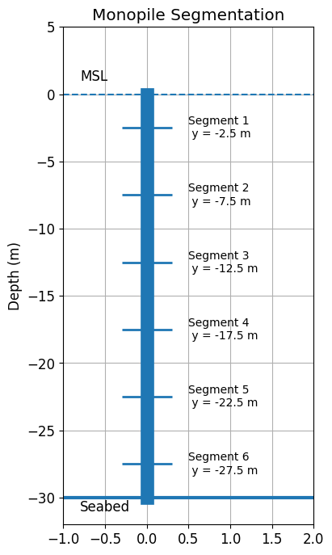

```python
# ---------------------------------------------------
# Plot Monopile Segmentation
# ---------------------------------------------------

fig, ax = plt.subplots(figsize=(4,8))

# Draw pile
ax.plot([0,0], [0,-d], linewidth=12)

# Draw segments
for i, yi in enumerate(y):

    ax.hlines(yi, -0.3, 0.3, linewidth=2)

    ax.text(
        0.5,
        yi,
        f"Segment {i+1}\n y = {yi} m",
        fontsize=10,
        verticalalignment='center'
    )

# Mean sea level
ax.axhline(0, linestyle='--')

ax.text(-0.8, 1, "MSL")

# Seabed
ax.axhline(-d, linewidth=3)

ax.text(-0.8, -d-1, "Seabed")

ax.set_xlim(-1,2)
ax.set_ylim(-32,5)

ax.set_title("Monopile Segmentation")

ax.set_ylabel("Depth (m)")

ax.grid(True)

plt.show()
```

```python
# ---------------------------------------------------
# Wave Phase Angle
# ---------------------------------------------------

# Phase angle in degrees
theta_deg = 90

# Convert to radians
theta = np.radians(theta_deg)

print(f"Phase Angle = {theta_deg} deg")
```

```
Phase Angle = 90 deg
```

```python
# ---------------------------------------------------
# Water Particle Velocity and Acceleration
# ---------------------------------------------------

# Horizontal particle velocity
u = (
    (0.5 * H * omega *
     np.cosh(k * (d + y)))
    / np.cosh(k * d)
) * np.cos(theta)

# Horizontal particle acceleration
a = -(
    (0.5 * H * omega**2 *
     np.cosh(k * (d + y)))
    / np.cosh(k * d)
) * np.sin(theta)

# Print values
for i in range(len(y)):

    print(f"Segment {i+1}")
    print(f"Depth = {y[i]:5.1f} m")
    print(f"Velocity = {u[i]:8.4f} m/s")
    print(f"Acceleration = {a[i]:8.4f} m/s2")
    print("-"*40)
```

```
Segment 1
Depth =  -2.5 m
Velocity =   0.0000 m/s
Acceleration =  -1.0906 m/s2
----------------------------------------
Segment 2
Depth =  -7.5 m
Velocity =   0.0000 m/s
Acceleration =  -0.9354 m/s2
----------------------------------------
Segment 3
Depth = -12.5 m
Velocity =   0.0000 m/s
Acceleration =  -0.8181 m/s2
----------------------------------------
Segment 4
Depth = -17.5 m
Velocity =   0.0000 m/s
Acceleration =  -0.7341 m/s2
----------------------------------------
Segment 5
Depth = -22.5 m
Velocity =   0.0000 m/s
Acceleration =  -0.6800 m/s2
----------------------------------------
Segment 6
Depth = -27.5 m
Velocity =   0.0000 m/s
Acceleration =  -0.6534 m/s2
----------------------------------------
```

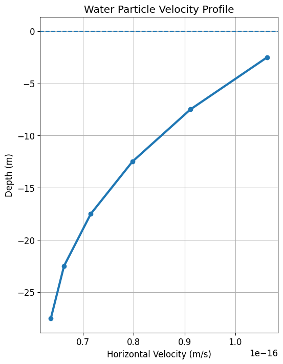

```python
# ---------------------------------------------------
# Plot Velocity Profile
# ---------------------------------------------------

plt.figure(figsize=(6,8))

plt.plot(u, y, marker='o', linewidth=3)

plt.axhline(0, linestyle='--')

plt.xlabel("Horizontal Velocity (m/s)")
plt.ylabel("Depth (m)")

plt.title("Water Particle Velocity Profile")

plt.grid(True)

plt.show()
```

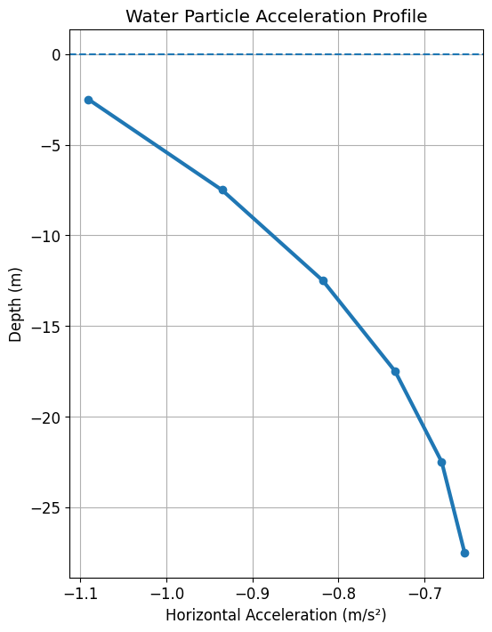

```python
# ---------------------------------------------------
# Plot Acceleration Profile
# ---------------------------------------------------

plt.figure(figsize=(6,8))

plt.plot(a, y, marker='o', linewidth=3)

plt.axhline(0, linestyle='--')

plt.xlabel("Horizontal Acceleration (m/s²)")
plt.ylabel("Depth (m)")

plt.title("Water Particle Acceleration Profile")

plt.grid(True)

plt.show()
```

### Engineering Interpretation

From the plots we can observe:

- Wave-induced motion is highest near the free surface
- Motion decreases with depth
- Acceleration dominates near wave crest/trough phases
- Offshore structures experience non-uniform loading over depth

This depth-varying behavior is very important in:

- Offshore wind monopiles
- Jacket structures
- Risers
- Subsea pipelines
- Offshore platforms

```python
# ---------------------------------------------------
# SECTION 4 — Morison Force Calculation
# ---------------------------------------------------

# Drag force per unit length (kN/m)
Fd = (
    0.5
    * Cd
    * rho
    * D
    * u
    * np.abs(u)
) / 1000

# Inertia force per unit length (kN/m)
Fi = (
    Cm
    * rho
    * (np.pi * D**2 / 4)
    * a
) / 1000

# Total force per unit length (kN/m)
Ft = Fd + Fi

# ---------------------------------------------------
# Print Results
# ---------------------------------------------------

for i in range(len(y)):

    print(f"Segment {i+1}")
    print(f"Depth              = {y[i]:6.1f} m")
    print(f"Drag Force         = {Fd[i]:8.3f} kN/m")
    print(f"Inertia Force      = {Fi[i]:8.3f} kN/m")
    print(f"Total Force        = {Ft[i]:8.3f} kN/m")
    print("-"*50)
```

```
Segment 1
Depth              =   -2.5 m
Drag Force         =    0.000 kN/m
Inertia Force      =   -4.495 kN/m
Total Force        =   -4.495 kN/m
--------------------------------------------------
Segment 2
Depth              =   -7.5 m
Drag Force         =    0.000 kN/m
Inertia Force      =   -3.855 kN/m
Total Force        =   -3.855 kN/m
--------------------------------------------------
Segment 3
Depth              =  -12.5 m
Drag Force         =    0.000 kN/m
Inertia Force      =   -3.372 kN/m
Total Force        =   -3.372 kN/m
--------------------------------------------------
Segment 4
Depth              =  -17.5 m
Drag Force         =    0.000 kN/m
Inertia Force      =   -3.026 kN/m
Total Force        =   -3.026 kN/m
--------------------------------------------------
Segment 5
Depth              =  -22.5 m
Drag Force         =    0.000 kN/m
Inertia Force      =   -2.803 kN/m
Total Force        =   -2.803 kN/m
--------------------------------------------------
Segment 6
Depth              =  -27.5 m
Drag Force         =    0.000 kN/m
Inertia Force      =   -2.693 kN/m
Total Force        =   -2.693 kN/m
--------------------------------------------------
```

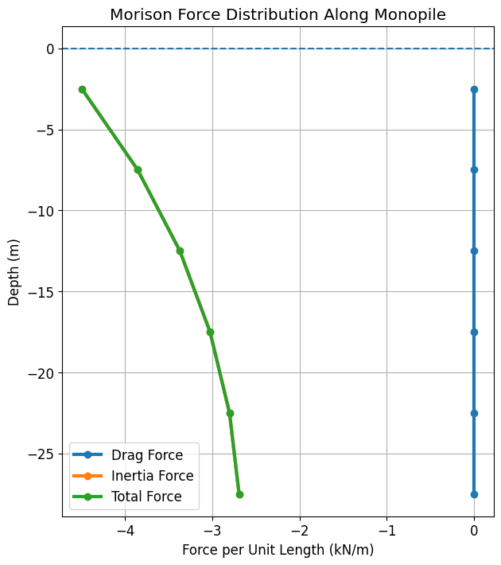

```python
# ---------------------------------------------------
# Plot Drag, Inertia and Total Force
# ---------------------------------------------------

plt.figure(figsize=(7,8))

plt.plot(Fd, y, marker='o', linewidth=3, label='Drag Force')
plt.plot(Fi, y, marker='o', linewidth=3, label='Inertia Force')
plt.plot(Ft, y, marker='o', linewidth=3, label='Total Force')

plt.axhline(0, linestyle='--')

plt.xlabel("Force per Unit Length (kN/m)")
plt.ylabel("Depth (m)")

plt.title("Morison Force Distribution Along Monopile")

plt.grid(True)

plt.legend()

plt.show()
```

```python
# ---------------------------------------------------
# Integrate Total Force Along Pile
# ---------------------------------------------------

# Total hydrodynamic force (kN)
F_total = np.sum(Ft * dz)

print(f"\nTotal Hydrodynamic Force = {F_total:.2f} kN")
```

```
Total Hydrodynamic Force = -101.22 kN
```